# Birthweight and DNA methylation age acceleration

Edward Bruce Quinn

2023-02-04

```r
library(meffil)
#options(mc.cores=1)


library(tidyverse)
library(readxl)
library(rebus)
library(ewastools)
library(kableExtra)
library(gtools)
library(rlist)
library(broom)
library(lmtest)
library(sandwich)
library(scattermore)
library(janitor)
library(PCAtools)
library(corrplot)
library(GGally)
library(prediction)
library(ggVennDiagram)
library(ggpubr)
library(performance)
library(sesame)
library(parallel)
library(doParallel)
library(ComplexHeatmap)
library(circlize)
library(betareg)
library(table1)
library(DT)
library(DNAmArray)
library(DiagrammeR)
library(lmerTest)
library(jtools)
library(interactions)
library(performance)
library(rmcorr)
library(outliers)
library(rebus)
library(data.table)



mutate <- dplyr::mutate
select <- dplyr::select
rename <- dplyr::rename
or <- rebus::or


library(here)

here <- here::here
```

# Meffil QC

## read in data

```r
df5 <- read.csv(file = here("data","sv_dnam_age_pub_df5_20221209.csv"))

# Dropped a total of 332 samples there.496-332 = 164 idat files

cat("We have",nrow(df5),"idat files remaining and",
    length(unique(paste0(df5$dyad,df5$num))),
    "unique individuals remaining.")
```

```
## We have 164 idat files remaining and 68 unique individuals remaining.
```

```r
# Read in age at sample collection

ages <- read_csv(here("data","age_at_sample_collection_20220908.csv"))

bdf <- df5 %>%
  left_join(ages, by = c("methylation_id" = "sample"))
```

## perform QC

```r
if(file.exists(here("output","qc.objects.baby.Robj"))) {

  load(here("output","qc.objects.baby.Robj"))

} else {

qc.objects.baby <- meffil.qc(bdf, verbose=TRUE)
save(qc.objects.baby,file = here("output","qc.objects.baby.Robj"))

}



 qc.parameters <- meffil.qc.parameters(
    beadnum.samples.threshold             = 0.1,
    detectionp.samples.threshold          = 0.1,
    detectionp.cpgs.threshold             = 0.1,
    beadnum.cpgs.threshold                = 0.1,
    sex.outlier.sd                        = 5
)


# Get quality control summary reports

if(file.exists(here("output","qcsummary.baby.Robj"))) {

  load(here("output","qcsummary.baby.Robj"))

} else {

 qc.summary.baby <- meffil.qc.summary(
    qc.objects.baby,
    parameters = qc.parameters
 )

 save(qc.summary.baby, file = here("output","qcsummary.baby.Robj"))

 meffil.qc.report(qc.summary.baby,
                  output.file = here("output","qc.report.baby.html"))

}


# List the quality control outliers


outlier.baby <- qc.summary.baby$bad.samples
table(outlier.baby$issue)
```

```
##
##           Control probe (bisulfite1)           Control probe (bisulfite2)
##                                    1                                    1
##             Control probe (dye.bias) Control probe (extension.G.12719506)
##                                    1                                    1
## Control probe (extension.G.74666473) Control probe (extension.R.21752326)
##                                    1                                    1
## Control probe (extension.R.63642461)        Control probe (hybe.21771417)
##                                    1                                    1
##        Control probe (hybe.28684356)        Control probe (hybe.39782321)
##                                    1                                    1
##   Control probe (nonpoly.G.23663352)   Control probe (nonpoly.G.38796356)
##                                    1                                    1
##   Control probe (nonpoly.R.18773482)   Control probe (nonpoly.R.24701411)
##                                    1                                    1
##                Control probe (normA)                Control probe (normC)
##                                    1                                    1
##                Control probe (normG)                Control probe (normT)
##                                    1                                    1
##            Control probe (oob.G.99%)     Control probe (spec1.G.51804467)
##                                    1                                    1
##     Control probe (spec1.G.65735497)     Control probe (spec1.R.28618334)
##                                    1                                    1
##     Control probe (spec1.R.46779338)          Control probe (spec1.ratio)
##                                    1                                    1
##         Control probe (spec1.ratio1)         Control probe (spec1.ratio2)
##                                    1                                    1
##     Control probe (spec2.R.17661470)     Control probe (spec2.R.29662396)
##                                    1                                    1
##     Control probe (spec2.R.34730329)          Control probe (spec2.ratio)
##                                    1                                    1
##              Control probe (stain.G)              Control probe (stain.R)
##                                    1                                    1
##                    Detection p-value           Methylated vs Unmethylated
##                                    1                                    2
##                         Sex mismatch                    X-Y ratio outlier
##                                    2                                    1
```

```r
index.baby <- outlier.baby$issue %in% c("Control probe (dye.bias)",
                              "Methylated vs Unmethylated",
                              "X-Y ratio outlier",
                              "Low bead numbers",
                              "Detection p-value",
                              "Sex mismatch",
                              "Control probe (bisulfite1)",
                              "Control probe (bisulfite2)")

outlier.baby <- outlier.baby[index.baby,]
```

# Contamination check

Use ewastools package for this.

```r
if(file.exists(here("output","snps.RDS"))){

  snps <- readRDS(file = here("output","snps.RDS"))

} else {

meth <- read_idats(bdf$Basename,quiet = FALSE)

detectionP <- ewastools::detectionP
mask <- ewastools::mask
correct_dye_bias <- ewastools::correct_dye_bias
dont_normalize <- ewastools::dont_normalize

# get betas
beta <- meth %>% detectionP %>% mask(0.01) %>% correct_dye_bias %>% dont_normalize

# get snps
snps <- meth$manifest[probe_type=="rs",index]
snps <- beta[snps,]

saveRDS(snps, file = here("output","snps.RDS"))

rm(meth)
rm(beta)

}


genotypes <- call_genotypes(snps,learn=FALSE)

bdf$outlier <- snp_outliers(genotypes)

contam <- bdf[bdf$outlier > -4,c("Sample_Name","outlier")]

contam %>% kbl(caption="Samples identified as contaminated by ewastools") %>% kable_styling("hover",full_width=F)
```

Samples identified as contaminated by ewastools

|  | Sample_Name | outlier |
| --- | --- | --- |
| 56 | SV001b.b.1.2 | -3.463359 |

# SeSame noob

Get noob corrected betas for the epigenetic clock.

```r
if(file.exists(here("data", "sv_babies_noob_betas.rds"))) {

noobBetas <- readRDS(file = here("data", "sv_babies_noob_betas.rds"))

} else {


 noobBetas <- do.call(cbind, lapply(bdf$Basename, function(pfx) {
    getBetas(noob(readIDATpair(pfx)), mask = F)
 }))



 colnames(noobBetas) <- bdf$methylation_id

 saveRDS(noobBetas, file = here("data","sv_babies_noob_betas.rds"))

}
```

> Initial quality control indicates that SV001b.b.1.2 fails multiple QC checks and SV014b.b.1.1 fails the sex check. Let’s remove these two prior to uploading data to the epigenetic clock.

## prepare data for epigenetic clock

```r
failed_qc <- c("SV001b.b.1.2","SV014b.b.1.1")


clock <- bdf %>%
  filter(methylation_id != "SV001b.b.1.2") %>%
  filter(methylation_id != "SV014b.b.1.1") # Lose 2 samples. N = 162.


# Reformat the noob betas object obtained in the chunk above this one
# and filter them for the probes needed for the epigenetic clock.

noobBetas <- as.data.frame(noobBetas)
noobBetas$Name <- rownames(noobBetas)
probes <- read.csv(here("data","datMiniAnnotation3.csv"))


# get betas for Horvath's probe list
fil.noob.betas <- merge(probes, noobBetas, by = "Name", all.x = TRUE, all.y = FALSE)
nrow(fil.noob.betas) # 30084 is what we need

fil.noob.betas[1:10,1:10]


# remove extra columns
fil.noob.betas <- fil.noob.betas[-c(2:7)]

colnames(fil.noob.betas)[1] <- "ProbeID"

# Now remove the two samples failing QC: SV001b.b.1.2 AND SV014b.b.1.1

fil.noob.betas <- fil.noob.betas %>%
  select(-failed_qc)

cn <- colnames(fil.noob.betas[-1])

link <- match(cn,clock$methylation_id)

cc2 <- clock[link,]

identical(colnames(fil.noob.betas[-1]),cc2$methylation_id)

write.csv(cc2,
          file = here("data","epigenetic_clock_samplesheet.csv"),
          row.names = F)
write.csv(fil.noob.betas,
          row.names = F,
          file = here("data","epigenetic_clock_betas.csv"))
```

Upload the data to the epigenetic clock website using the “New Methylation Age Calculator Website”. Get the file emailed to you from [Steve Horvath’s epigenetic age calculator website](https://dnamage.genetics.ucla.edu/home) afterwards.

## format epigenetic age data

```r
# Read in output from Horvath's website
mage <- read.csv(here("data","epigenetic_clock_betas.output.csv"))

# Create a data frame of problematic samples by the epigenetic clock
# quality control checks

gs <- mage %>%
  filter(corSampleVSgoldstandard < 0.80) %>%
  select(methylation_id)

clock_sex_checks <- mage %>%
  mutate(problem_sex = case_when(
    predictedGender == "female" & Female == 1 ~ FALSE,
    predictedGender == "male" & Female == 0 ~ FALSE,
    predictedGender == "female" & Female == 0 ~ TRUE,
    predictedGender == "male" & Female == 1 ~ TRUE,
    predictedGender == "Unsure" ~ TRUE)) %>%
  filter(problem_sex == TRUE)

# Which samples fail these two quality control checks that
# are part of the epigenetic clock? None.




# Get replicate status and subset for all replicates.
# Use this to get list of which samples to average.

# Since we have filtered samples at this point, the original
# vector labeling replicates is no longer accurate. Make a
# new one.

reps <- bdf %>%
  group_by(dyad,timepoint) %>%
  filter(n()>1) %>%
  ungroup() %>%
  select(methylation_id)

bdf$replicate <- ifelse(bdf$methylation_id %in% reps$methylation_id, TRUE, FALSE)

rav <- bdf %>%
  select(methylation_id,replicate,dyad,timepoint) %>%
  filter(replicate == TRUE) %>%
  group_by(dyad,timepoint) %>%
  select(methylation_id)

toAverage <- by(rav$methylation_id,rav$dyad,print)

# average by replicates using the avgReps function and store the new
# rows in a data frame

# write function to average replicates

avgReps <- function(repsToAverage){

  dr <- mage[mage$methylation_id %in% repsToAverage,]

  row <- dr %>%
    summarise_if(is.numeric, mean, na.rm = TRUE)

  x <- smartbind(dr,row,fill="replaceme")

  dex <- grep("replaceme",x[nrow(x), ])

  fillers <- x[nrow(x) - 1, dex]

  fin <- replace(x[nrow(x), ], dex, fillers)

  return(fin[nrow(fin),])
}

# Average the replicates using the avgReps function

rep1 <- avgReps(toAverage$SV15)
rep2 <- avgReps(toAverage$SV18)
rep3 <- avgReps(toAverage$SV61)
rep4 <- avgReps(toAverage$SV67)


averaged_reps <- bind_rows(rep1,rep2,rep3,rep4)



# remove replicates rows from original epigenetic age
# data frame and then
# Add back in the rows with the average replicate
# values. For character vectors, such as slide
# and position on slide, just selecting a single
# value because these cannot be averaged. That's
# fine as long as we're only using numeric variables.

mage2 <- mage %>%
  filter(!(methylation_id %in% rav$methylation_id)) %>%
  bind_rows(averaged_reps) # This step takes us from n=162 to n=156

cat("There were",length(rav$methylation_id),"replicate samples total out of",
    nrow(mage),"samples in epigenetic age analyses, corresponding to",
    nrow(averaged_reps),"unique individuals for whom we had replicates samples.")
cat("These were removed from the data, averaged by replicate, and
    then added back into the data, leaving",
    nrow(mage2),"samples.")
```

## covariates

```r
# calculate maternal bmi, dichotomize birthweight and parity

mage2 <- mage2 %>%
  mutate(bmi = mwgt/((mhgt/100)^2))

mage2$kbwgt <- mage2$bwgt/1000
mage2$bhilo <- factor(ifelse(mage2$bwgt > 2500,"Normal","Low"),
                    levels = c("Low","Normal"))
mage2$Parity <- factor(ifelse(mage2$parity_bf_birth > 0,"Multigravida","Primigravida"),
                 levels = c("Primigravida","Multigravida"))
```

> Label covariates

```r
mage2$Sex <- factor(ifelse(mage2$Female==1,"Female","Male"), levels = c("Female","Male"))

mage2$Delivery_Method <- factor(ifelse(mage2$pcsec==1,"Cesarean","Vaginal"),
                              levels = c("Cesarean","Vaginal"))


mage2$Alcohol_in_Pregnancy <- factor(ifelse(mage2$palco==1,"Alcohol","No Alcohol"),
                                   levels = c("Alcohol","No Alcohol"))


mage2$Age_Acceleration <- mage2$AgeAccelerationResidual
mage2$Low_Birthweight <- mage2$bhilo
mage2$Time_Point <- factor(mage2$timepoint, levels = c("birth","6 months","1 year","2 years","3 years"),
                           labels = c("Birth","6 months","1 year","2 years","3 years"))

mage2$Maternal_BMI <- mage2$bmi
mage2$Maternal_Age <- mage2$mom_age

mage2$War_Stress <- mage2$swar
mage2$Chronic_Stress <- mage2$schronic

mage2$Birthweight <- mage2$bwgt

mage2$Gestational_Age <- mage2$ga_meth/7
```

# Analysis

What was the total number of observations?

```r
nrow(mage2)
```

```
## [1] 156
```

What was the number of unique individuals?

```r
length(unique(mage2$dyad))
```

```
## [1] 67
```

What was the average number of observations per individual?

```r
nrow(mage2)/length(unique(mage2$dyad))
```

```
## [1] 2.328358
```

How many of the babies are high birth weight? How many babies were preterm?

```r
mage2 %>%
  mutate(hbw = if_else(Birthweight > 4000, TRUE, FALSE)) %>%
  select(methylation_id,hbw,bwgt) %>%
  filter(hbw == TRUE)
```

```
##                           methylation_id  hbw bwgt
## ...1 SV033b.1A.1.1 (NOT 7-10-18) - eq100 TRUE 4040
## ...2                      SV033bb.3A.1.1 TRUE 4040
## ...3                      SV018bb.3A.2.1 TRUE 4075
## ...4                         SV018bb.2.1 TRUE 4075
## ...5                           SV033bb.2 TRUE 4040
## ...6                        SV018bb.1A.2 TRUE 4075
## ...7        SV033bb.2A.1.1 (NOT 11/8/18) TRUE 4040
## 2                  SV018bb.2A.1.1 - dup3 TRUE 4075
```

```r
mage2 %>%
  filter(Time_Point == "Birth") %>%
  mutate(preterm = if_else(Gestational_Age < 37, TRUE, FALSE)) %>%
  select(preterm) %>%
  table()
```

```
## preterm
## FALSE  TRUE
##    61     4
```

# EDA

> Look at the DNA methylation age data

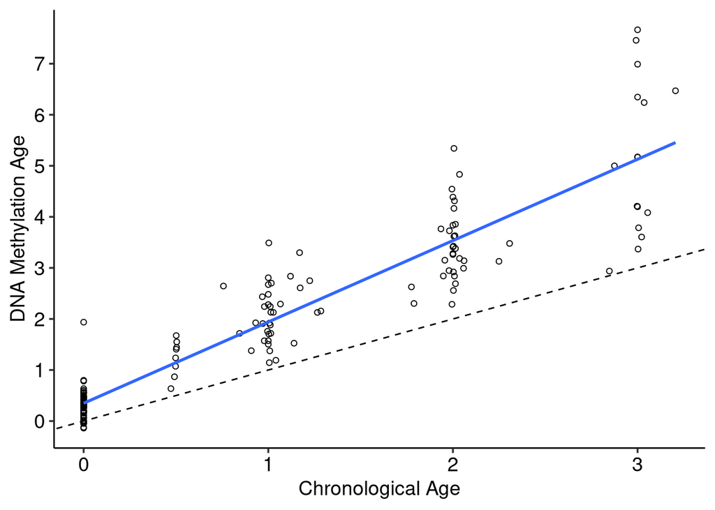

```r
ggplot(data = mage2, aes(x = Age, y = DNAmAge)) +
  geom_point(shape = 21) +
  theme_pubr(base_size = 14) +
  scale_x_continuous(breaks = c(0:7), labels = c(0:7)) +
  scale_y_continuous(breaks = c(0:7), labels = c(0:7)) +
  xlab("Chronological Age") +
  ylab("DNA Methylation Age") +
  geom_smooth(method="lm",se=FALSE) +
  # annotate("text",x = 0.25, y = 6,
  #          label = label1,
  #          hjust = 0, fontface = 2) +
  geom_abline(intercept = 0, slope = 1, lty = "dashed")
```

There is one point that stands out at the at birth time point. Which person is this?

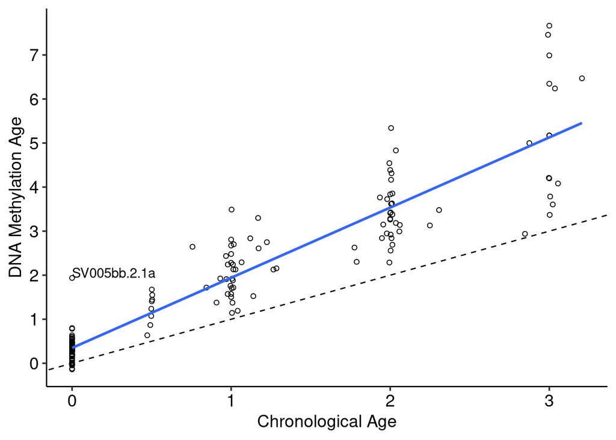

```r
ggplot(data = mage2, aes(x = Age, y = DNAmAge)) +
  geom_point(shape = 21) +
  theme_pubr(base_size = 14) +
  scale_x_continuous(breaks = c(0:7), labels = c(0:7)) +
  scale_y_continuous(breaks = c(0:7), labels = c(0:7)) +
  xlab("Chronological Age") +
  ylab("DNA Methylation Age") +
  geom_smooth(method="lm",se=FALSE) +
  # annotate("text",x = 0.25, y = 6,
  #          label = label1,
  #          hjust = 0, fontface = 2) +
  geom_abline(intercept = 0, slope = 1, lty = "dashed") +
  geom_text(aes(label=ifelse(DNAmAge > 1 &
                               timepoint =="birth",
                             as.character(methylation_id),'')),hjust=0,vjust=0)
```

Do a formal test to see if this value is indeed an outlier.

```r
outlier_birth <- grubbs.test(mage2[mage2$timepoint=="birth","DNAmAge"])

outlier_birth
```

```
##
##  Grubbs test for one outlier
##
## data:  mage2[mage2$timepoint == "birth", "DNAmAge"]
## G = 5.51844, U = 0.51673, p-value = 4.279e-09
## alternative hypothesis: highest value 1.93706962841998 is an outlier
```

SV005.2.1a is an outlier by the grubbs test. Remove from all further analyses

```r
dim(mage2)
```

```
## [1] 156 166
```

```r
mage2 <- mage2 %>%
  filter(methylation_id != "SV005bb.2.1a")

dim(mage2) # 155 observations left
```

```
## [1] 155 166
```

```r
length(unique(mage2$dyad)) # 67 unique dyads left.
```

```
## [1] 67
```

## Table 1

```r
table1(~ DNAmAge + Birthweight + Low_Birthweight + Sex + Gestational_Age + Maternal_Age + Parity + Delivery_Method + Alcohol_in_Pregnancy + Maternal_BMI + War_Stress + Chronic_Stress | Time_Point, data = mage2,
       overall = FALSE, topclass="Rtable1-zebra")
```

|  | Birth (N=64) | 6 months (N=8) | 1 year (N=35) | 2 years (N=32) | 3 years (N=16) |
| --- | --- | --- | --- | --- | --- |
| DNAmAge |  |  |  |  |  |
| Mean (SD) | 0.286 (0.213) | 1.24 (0.356) | 2.12 (0.573) | 3.43 (0.718) | 5.17 (1.52) |
| Median [Min, Max] | 0.287 [-0.138, 0.799] | 1.32 [0.636, 1.67] | 2.13 [1.14, 3.49] | 3.33 [2.29, 5.34] | 5.08 [2.94, 7.66] |
| Birthweight |  |  |  |  |  |
| Mean (SD) | 2890 (553) | 2850 (546) | 2920 (586) | 2890 (588) | 2910 (613) |
| Median [Min, Max] | 3010 [1820, 4080] | 3050 [1990, 3510] | 3060 [1900, 4080] | 2890 [1900, 4080] | 2730 [1990, 4080] |
| Low_Birthweight |  |  |  |  |  |
| Low | 17 (26.6%) | 3 (37.5%) | 10 (28.6%) | 9 (28.1%) | 4 (25.0%) |
| Normal | 47 (73.4%) | 5 (62.5%) | 25 (71.4%) | 23 (71.9%) | 12 (75.0%) |
| Sex |  |  |  |  |  |
| Female | 33 (51.6%) | 6 (75.0%) | 22 (62.9%) | 21 (65.6%) | 10 (62.5%) |
| Male | 31 (48.4%) | 2 (25.0%) | 13 (37.1%) | 11 (34.4%) | 6 (37.5%) |
| Gestational_Age |  |  |  |  |  |
| Mean (SD) | 39.6 (1.45) | 39.3 (1.37) | 39.8 (1.16) | 39.7 (1.21) | 39.6 (1.16) |
| Median [Min, Max] | 39.8 [33.2, 41.5] | 39.8 [37.2, 40.8] | 39.8 [36.3, 41.4] | 39.8 [36.3, 41.4] | 39.6 [37.2, 41.4] |
| Missing | 0 (0%) | 1 (12.5%) | 2 (5.7%) | 2 (6.3%) | 0 (0%) |
| Maternal_Age |  |  |  |  |  |
| Mean (SD) | 17.2 (3.60) | 18.6 (3.87) | 18.5 (4.69) | 18.3 (4.79) | 18.5 (5.29) |
| Median [Min, Max] | 17.0 [13.0, 33.0] | 18.0 [14.0, 25.0] | 17.0 [14.0, 33.0] | 17.0 [14.0, 33.0] | 17.0 [14.0, 33.0] |
| Missing | 3 (4.7%) | 1 (12.5%) | 2 (5.7%) | 2 (6.3%) | 0 (0%) |
| Parity |  |  |  |  |  |
| Primigravida | 53 (82.8%) | 6 (75.0%) | 26 (74.3%) | 24 (75.0%) | 14 (87.5%) |
| Multigravida | 8 (12.5%) | 1 (12.5%) | 7 (20.0%) | 6 (18.8%) | 2 (12.5%) |
| Missing | 3 (4.7%) | 1 (12.5%) | 2 (5.7%) | 2 (6.3%) | 0 (0%) |
| Delivery_Method |  |  |  |  |  |
| Cesarean | 19 (29.7%) | 1 (12.5%) | 10 (28.6%) | 8 (25.0%) | 5 (31.3%) |
| Vaginal | 45 (70.3%) | 7 (87.5%) | 25 (71.4%) | 24 (75.0%) | 11 (68.8%) |
| Alcohol_in_Pregnancy |  |  |  |  |  |
| Alcohol | 7 (10.9%) | 1 (12.5%) | 2 (5.7%) | 2 (6.3%) | 1 (6.3%) |
| No Alcohol | 54 (84.4%) | 6 (75.0%) | 31 (88.6%) | 28 (87.5%) | 15 (93.8%) |
| Missing | 3 (4.7%) | 1 (12.5%) | 2 (5.7%) | 2 (6.3%) | 0 (0%) |
| Maternal_BMI |  |  |  |  |  |
| Mean (SD) | 25.9 (2.83) | 25.9 (2.41) | 25.9 (3.09) | 25.9 (3.10) | 25.2 (3.19) |
| Median [Min, Max] | 25.8 [21.0, 33.7] | 25.7 [23.0, 30.0] | 25.3 [21.0, 33.7] | 25.3 [21.0, 33.7] | 25.1 [21.0, 32.7] |
| Missing | 1 (1.6%) | 0 (0%) | 0 (0%) | 0 (0%) | 0 (0%) |
| War_Stress |  |  |  |  |  |
| Mean (SD) | 2.00 (1.07) | 1.13 (0.991) | 1.71 (0.987) | 1.72 (0.958) | 1.63 (0.885) |
| Median [Min, Max] | 2.00 [0, 5.00] | 1.50 [0, 2.00] | 2.00 [0, 3.00] | 2.00 [0, 3.00] | 2.00 [0, 3.00] |
| Chronic_Stress |  |  |  |  |  |
| Mean (SD) | 7.83 (3.15) | 6.38 (3.38) | 7.89 (3.38) | 8.22 (3.41) | 9.06 (3.09) |
| Median [Min, Max] | 8.50 [0, 13.0] | 6.00 [0, 10.0] | 9.00 [0, 13.0] | 9.00 [0, 13.0] | 9.50 [3.00, 13.0] |

## Correlation & Error Analyses

What is the correlation among unique individuals, with random selection of the time point of observation? What is the correlation among unique individuals, with specific selection for the latest date of sample collection for each unique individual?

```r
set.seed(456)
random_unique <- mage2 %>%
  group_by(dyad) %>%
  slice_sample(n = 1)

cor.test(random_unique$Age,random_unique$DNAmAge) # r = 0.93, p < 2.2e-16
```

```
##
##  Pearson's product-moment correlation
##
## data:  random_unique$Age and random_unique$DNAmAge
## t = 21.088, df = 65, p-value < 2.2e-16
## alternative hypothesis: true correlation is not equal to 0
## 95 percent confidence interval:
##  0.8945733 0.9590841
## sample estimates:
##       cor
## 0.9340659
```

```r
sd(random_unique$Age) # standard deviation = 0.884.
```

```
## [1] 0.8835524
```

```r
# Now select the latest observation from within each individual only:
last_obs <- mage2 %>%
  group_by(dyad) %>%
  slice_max(Age,n = 1)

cor.test(last_obs$Age,last_obs$DNAmAge) # r = 0.93, p < 2.2e-16
```

```
##
##  Pearson's product-moment correlation
##
## data:  last_obs$Age and last_obs$DNAmAge
## t = 20.488, df = 65, p-value < 2.2e-16
## alternative hypothesis: true correlation is not equal to 0
## 95 percent confidence interval:
##  0.8890618 0.9568684
## sample estimates:
##       cor
## 0.9305433
```

```r
sd(last_obs$Age) # standard deviation = 1.274349
```

```
## [1] 1.274349
```

```r
# Calculate median absolute error across all data

mage2$dev_all <- abs(mage2$DNAmAge - mage2$Age)
median(mage2$dev_all) # Median Absolute Error = 0.6010764 years
```

```
## [1] 0.6010764
```

```r
# Calculate correlation across all data, ignoring lack of independence

cor.test(mage2$DNAmAge,mage2$Age) # r = 0.93, p < 2.2e-16
```

```
##
##  Pearson's product-moment correlation
##
## data:  mage2$DNAmAge and mage2$Age
## t = 31.578, df = 153, p-value < 2.2e-16
## alternative hypothesis: true correlation is not equal to 0
## 95 percent confidence interval:
##  0.9065365 0.9494022
## sample estimates:
##       cor
## 0.9311155
```

## Table S1

```r
# Supplemental Table 1

# Calculate median absolute error at each timepoint:
err_all <- mage2 %>%
  group_by(Time_Point) %>%
  summarise(median(abs(DNAmAge - Age)))

kbl(err_all, caption = "Supplemental Table 1 - Median Absolute Error by Time Point",
    col.names = c("Time Point", "Median Absolute Error"),
    digits = 2) %>%
  kable_styling(full_width = F)
```

Supplemental Table 1 - Median Absolute Error by Time Point

| Time Point | Median Absolute Error |
| --- | --- |
| Birth | 0.29 |
| 6 months | 0.82 |
| 1 year | 0.99 |
| 2 years | 1.27 |
| 3 years | 2.15 |

## Variance Analysis

```r
library(PairedData)

# We actually need a wide data-set for this test.

wide <- mage2 %>%
  dplyr::select(dyad,Time_Point,DNAmAge) %>%
  tidyr::pivot_wider(names_from = Time_Point, values_from = DNAmAge)

# Meet assumptions of normality?
shapiro.test(wide$Birth)
```

```
##
##  Shapiro-Wilk normality test
##
## data:  wide$Birth
## W = 0.98688, p-value = 0.7323
```

```r
shapiro.test(wide$`1 year`)
```

```
##
##  Shapiro-Wilk normality test
##
## data:  wide$`1 year`
## W = 0.97483, p-value = 0.5885
```

```r
shapiro.test(wide$`2 years`)
```

```
##
##  Shapiro-Wilk normality test
##
## data:  wide$`2 years`
## W = 0.962, p-value = 0.3112
```

```r
shapiro.test(wide$`3 years`)
```

```
##
##  Shapiro-Wilk normality test
##
## data:  wide$`3 years`
## W = 0.93821, p-value = 0.3277
```

```r
# yes, in all cases


wide %>%
  select(Birth,`1 year`) %>%
  tidyr::drop_na() %>%
  summarise(variance_birth = var(Birth),variance_1 = var(`1 year`),n = n()) # sample size = 32
```

```
## # A tibble: 1 × 3
##   variance_birth variance_1     n
##            <dbl>      <dbl> <int>
## 1         0.0262      0.335    32
```

```r
grambsch.Var.test(wide$Birth,wide$`1 year`) # z = -4.0388, p-value = 5.373e-05
```

```
##
##  Paired Grambsch test
##
## data:  wide$Birth and wide$`1 year`
## z = -4.0388, p-value = 5.373e-05
## alternative hypothesis: true ratio of variances is not equal to 1
```

```r
wide %>%
  select(Birth,`2 years`) %>%
  tidyr::drop_na() %>%
  summarise(variance_birth = var(Birth),variance_2 = var(`2 years`),n = n()) # sample size = 29
```

```
## # A tibble: 1 × 3
##   variance_birth variance_2     n
##            <dbl>      <dbl> <int>
## 1         0.0318      0.485    29
```

```r
grambsch.Var.test(wide$Birth,wide$`2 years`) # z = -3.1516, p-value = 0.001624
```

```
##
##  Paired Grambsch test
##
## data:  wide$Birth and wide$`2 years`
## z = -3.1516, p-value = 0.001624
## alternative hypothesis: true ratio of variances is not equal to 1
```

```r
wide %>%
  select(Birth,`3 years`) %>%
  tidyr::drop_na() %>%
  summarise(variance_birth = var(Birth),variance_3 = var(`3 years`),n = n()) # sample size = 16
```

```
## # A tibble: 1 × 3
##   variance_birth variance_3     n
##            <dbl>      <dbl> <int>
## 1         0.0354       2.31    16
```

```r
grambsch.Var.test(wide$Birth,wide$`3 years`) # z = -4.3993, p-value = 1.086e-05
```

```
##
##  Paired Grambsch test
##
## data:  wide$Birth and wide$`3 years`
## z = -4.3993, p-value = 1.086e-05
## alternative hypothesis: true ratio of variances is not equal to 1
```

```r
wide %>%
  select(`1 year`,`2 years`) %>%
  tidyr::drop_na() %>%
  summarise(variance_1 = var(`1 year`),variance_2 = var(`2 years`),n = n())  # sample size = 31
```

```
## # A tibble: 1 × 3
##   variance_1 variance_2     n
##        <dbl>      <dbl> <int>
## 1      0.330      0.532    31
```

```r
grambsch.Var.test(wide$`1 year`,wide$`2 years`) # z = -1.1598, p-value = 0.2461 not significant
```

```
##
##  Paired Grambsch test
##
## data:  wide$`1 year` and wide$`2 years`
## z = -1.1598, p-value = 0.2461
## alternative hypothesis: true ratio of variances is not equal to 1
```

```r
wide %>%
  select(`1 year`,`3 years`) %>%
  tidyr::drop_na() %>%
  summarise(variance_1 = var(`1 year`),variance_3 = var(`3 years`),n = n()) # sample size = 16
```

```
## # A tibble: 1 × 3
##   variance_1 variance_3     n
##        <dbl>      <dbl> <int>
## 1      0.432       2.31    16
```

```r
grambsch.Var.test(wide$`1 year`,wide$`3 years`) # z = -4.0983, p-value = 4.162e-05
```

```
##
##  Paired Grambsch test
##
## data:  wide$`1 year` and wide$`3 years`
## z = -4.0983, p-value = 4.162e-05
## alternative hypothesis: true ratio of variances is not equal to 1
```

```r
wide %>%
  select(`2 years`,`3 years`) %>%
  tidyr::drop_na() %>%
  summarise(variance_2 = var(`2 years`),variance_3 = var(`3 years`),n = n()) # sample size = 16
```

```
## # A tibble: 1 × 3
##   variance_2 variance_3     n
##        <dbl>      <dbl> <int>
## 1      0.561       2.31    16
```

```r
grambsch.Var.test(wide$`2 years`,wide$`3 years`) # z = -3.4439, p-value = 0.0005733
```

```
##
##  Paired Grambsch test
##
## data:  wide$`2 years` and wide$`3 years`
## z = -3.4439, p-value = 0.0005733
## alternative hypothesis: true ratio of variances is not equal to 1
```

```r
# sample size for the test above?

# All of these variance comparisons are significant
# except for the comparison between 1 year and 2 years.
# The six month timepoint is left out because the sample
# size is too small to estimate a variance.


# Detach the PairedData package because it has it's own summary function
# that I don't want to deal with.

detach("package:PairedData", unload=TRUE)
```

## Repeated Measures Correlation Analysis

```r
b_1 <- rmcorr(participant = dyad, measure1 = Age,
              measure2 = DNAmAge, dataset =  mage2)

b_1 # r = 0.95, p = 1.57431e-44
```

```
##
## Repeated measures correlation
##
## r
## 0.9465672
##
## degrees of freedom
## 87
##
## p-value
## 1.57431e-44
##
## 95% confidence interval
## 0.9195879 0.9646612
```

## At birth analysis

```r
# differences in ageaccel by birthweight category or sex at birth?

bdat <- mage2[mage2$Time_Point=="Birth",]

shapiro.test(bdat$AgeAccelerationResidual) # normally distributed
```

```
##
##  Shapiro-Wilk normality test
##
## data:  bdat$AgeAccelerationResidual
## W = 0.98688, p-value = 0.7323
```

```r
t.test(bdat$AgeAccelerationResidual ~ bdat$Low_Birthweight) # pval = 0.6791
```

```
##
##  Welch Two Sample t-test
##
## data:  bdat$AgeAccelerationResidual by bdat$Low_Birthweight
## t = -0.41816, df = 27.67, p-value = 0.6791
## alternative hypothesis: true difference in means between group Low and group Normal is not equal to 0
## 95 percent confidence interval:
##  -0.1521373  0.1005767
## sample estimates:
##    mean in group Low mean in group Normal
##          -0.08565019          -0.05986992
```

```r
t.test(bdat$AgeAccelerationResidual ~ bdat$Sex) # pval = 0.2099
```

```
##
##  Welch Two Sample t-test
##
## data:  bdat$AgeAccelerationResidual by bdat$Sex
## t = -1.2682, df = 57.197, p-value = 0.2099
## alternative hypothesis: true difference in means between group Female and group Male is not equal to 0
## 95 percent confidence interval:
##  -0.17501627  0.03928366
## sample estimates:
## mean in group Female   mean in group Male
##          -0.09959054          -0.03172424
```

```r
# Is the overall DNA methylation age different from zero at birth?

t.test(bdat$DNAmAge)
```

```
##
##  One Sample t-test
##
## data:  bdat$DNAmAge
## t = 10.71, df = 63, p-value = 8.064e-16
## alternative hypothesis: true mean is not equal to 0
## 95 percent confidence interval:
##  0.2324439 0.3390886
## sample estimates:
## mean of x
## 0.2857662
```

```r
# Yes it is. Average = 0.2857662, pval = 8.064e-16.
```